# warmup01-balaji-veeramani

Balaji Veeramani

February 4, 2019

# Obi-Wan Kenobi

[figure not shown]

Obi-Wan in A New Hope

| Description | Value |
| --- | --- |
| Homeworld | Stewjon |
| Born | 57 BBY |
| Died | 0 BBY |
| Species | Humane |
| Gender | Male |
| Height | 1.82 meters |
| Mass | 81 kilograms |
| Eye color | Gray-blue |
| Skin color | Light |

**Obi-wan Kenobi to Anakin Skywalker:**

> “You were the Chosen One! It was said that you would destroy the Sith, not join them! Bring balance to the Force, not leave it in darkness!”

*Information on this character was retrieved from [this website](https://starwars.fandom.com/wiki/Obi-Wan_Kenobi/).*

# Buffalo Chicken Wing Recipe

*This recipe is best enjoyed in the fall.*

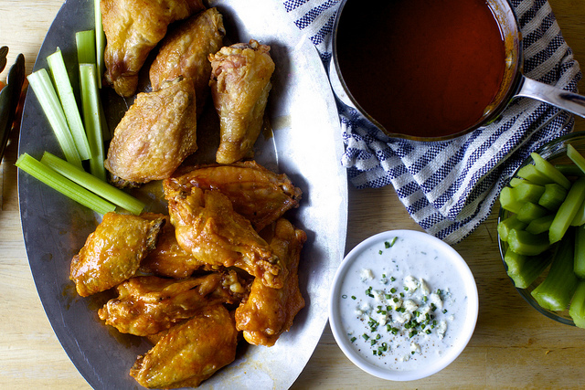

Homemade Buffalo Wings

### Ingredients

- 1 to 4 pounds chicken wings
- 1 1/2 to 2 teaspoons baking powder
- 1 to 4 teaspoons kosher salt
- 2 tablespoons hot sauce
- 1 1/2 to 2 tablespoons unsalted butter

### Tools

- Baking sheet
- Oven-safe cooling rack
- Tongs
- Medium saucepan

### Instructions

1. Line baking sheet with foil and set colling rack on top
2. Pat wings dry and toss with baking powder and salt
3. Place in regrigerator uncovered for 8 to 24 hours
4. Heat ovens to 450 degrees and bake wings for 20 minutes
5. Flip wings with tongs, bake for 15 minutes, flip them again, and then **cook again** for 15 minutes.
6. Combine 2 tablespoons of hot sauce and 2 tablespoons of unsalted butter and heat until melted
7. Roll each wing in sauce and serve with cellery or carrot

## Blue Cheese Dressing Variation

### Ingredients

- 1/3 cup buttermilk
- 1/3 cup mayonnaise
- 1/3 cup sour cream
- Juice of half a lemon
- 2 teaspoons white vinegar
- 1 small garlic clobe
- Salt and pepper
- 4 ounces blue cheese
- 2 tablespoons olives

### Instructions

1. Combine ingridents in a bowl
2. Stir until combined
3. Season **thoroughly** with salt and pepper

*These recipes were adapted from [this website](https://smittenkitchen.com/2019/01/baked-buffalo-wings/).*

The **Euclidean distance** between points **p** and **q** is the length of the *line segment* connecting them ($\overline{\textbf{pq}}$).

In *Cartesian coordinates*, if $\textbf{p} = (p_1, p_2,..., p_n)$ and $\textbf{q} = (q_1, q_2,..., q_n)$ are two points in *Euclidean n-space*, then the distance (d) from **p** to **q**, or from **q** to **p** is given by the *Pythagorean formula*:

$\begin{equation}\label{eq:1}\begin{split} \textit{d}(\textbf{p, q}) = \textit{d}(\textbf{q, p}) & = \sqrt{(q_1 - p_1)^2 + (q_2 - p_2)^2 + \cdot\cdot\cdot + (q_n - p_n)^2} \\ & = \sqrt{\sum\limits_{i = 1}^{n} (q_i - p_i)^2} \end{split}\label{eq:2} \end{equation}$

The position of a point in a Euclidean n-space is a *Euclidean vector*. So, p and q may be represented as Euclidean vectors, starting from the origin of the space (initial point) with their tips (terminal points) ending at the two points. The *Euclidean norm*, or **Euclidean length**, or **magnitude** of a vector measures the length of the vector:

$\ \| \textbf{p} \| = \sqrt{p_1^2 + p_2^2 + \cdot\cdot\cdot + p_n^2} = \sqrt{\textbf{p} \cdot \textbf{p}}$